# school_shootings_usa

Martin Butzbach Christensen

12/7/2021

```r
library(tidyverse)
```

```r
library(ggplot2)
library(ggridges)
```

```r
school_shootings <- read_csv("school-shootings-data.csv")
```

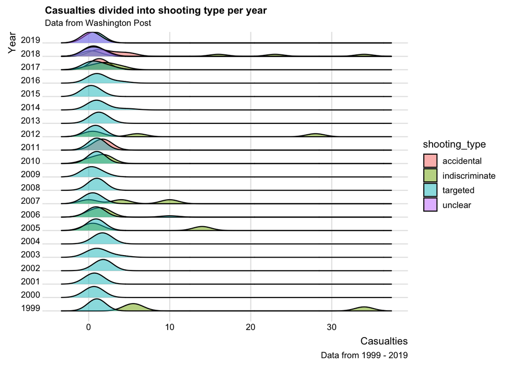

```r
school_shootings %>%
  #filter(shooting_type %in% c("targeted", "indiscriminate", "accidental or targeted", "targeted and indiscriminate", "acidental", "hostage suicide", "public suicide", "unclear")) %>%
  filter(!is.na (casualties)) %>%
  ggplot(aes(x = casualties,
             y = factor (year),
             fill = shooting_type)) +
  geom_density_ridges(alpha = 0.5,
                      scale = 0.9)  +
  theme_ridges(font_size = 10) +
  scale_x_continuous(breaks = seq(0, 100, 10),
                     labels = seq(0, 100, 10))+
  xlab("Casualties") +
  ylab("Year")+
  labs(title = "Casualties divided into shooting type per year", subtitle = "Data from Washington Post", caption = "Data from 1999 - 2019")
```

#This visualization is looking a bit messy. Therefore, it is probably not the best way to show what a want with this data. This is because the data is a bit to wide, and the ridges goes into each other.

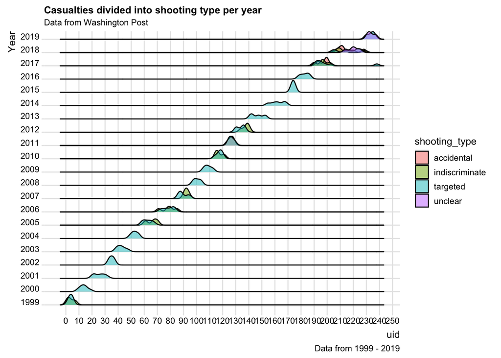

```r
school_shootings %>%
  #filter(shooting_type %in% c("targeted", "indiscriminate", "accidental or targeted", "targeted and indiscriminate", "acidental", "hostage suicide", "public suicide", "unclear")) %>%
  filter(!is.na (uid)) %>%
  ggplot(aes(x = uid,
             y = factor (year),
             fill = shooting_type)) +
  geom_density_ridges(alpha = 0.5,
                      scale = 0.9)  +
  theme_ridges(font_size = 10) +
  scale_x_continuous(breaks = seq(0, 250, 10),
                     labels = seq(0, 250, 10))+
  xlab("uid") +
  ylab("Year")+
  labs(title = "Casualties divided into shooting type per year", subtitle = "Data from Washington Post", caption = "Data from 1999 - 2019")
```

#In this visualization i tried to see, if there would be a difference if the incidents where divided into the cases insted of casualties.

#I will therefore make i line plot to see if if will show the data better.

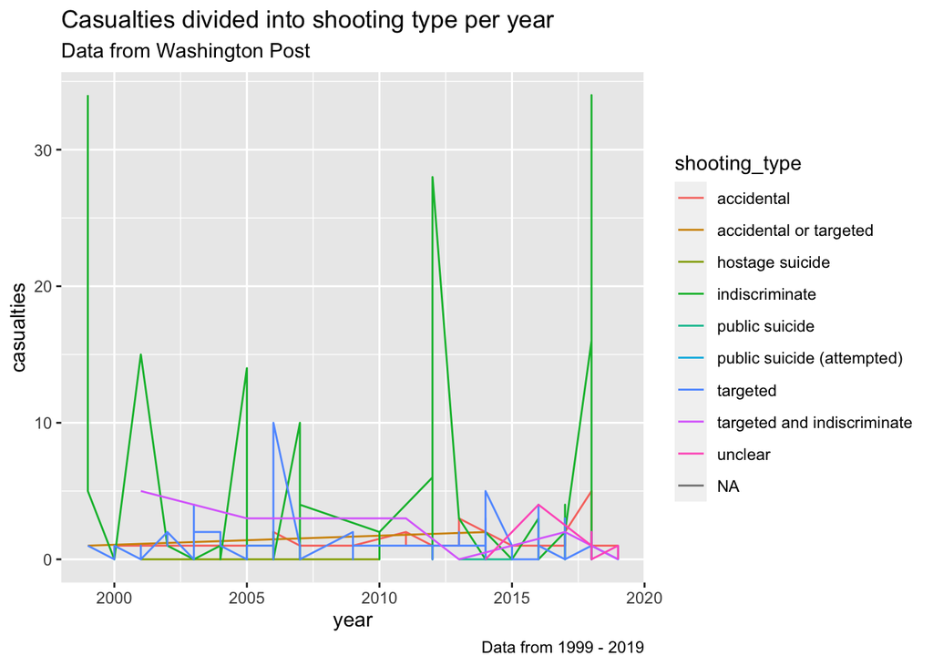

```r
school_shootings %>%
  ggplot(aes(x=year, y=casualties, color=shooting_type))+
  geom_line()+
  labs(title = "Casualties divided into shooting type per year", subtitle = "Data from Washington Post", caption = "Data from 1999 - 2019")
```

#In this line plot it is easier to see the different kind of shootings type divided into casualties per year. Where there i the first big green line before the year 2000, which is the events at Columbine High School. However, the data still looks a bit messy, and it can be difficult to see the category “targeted” which is the darker blue line.

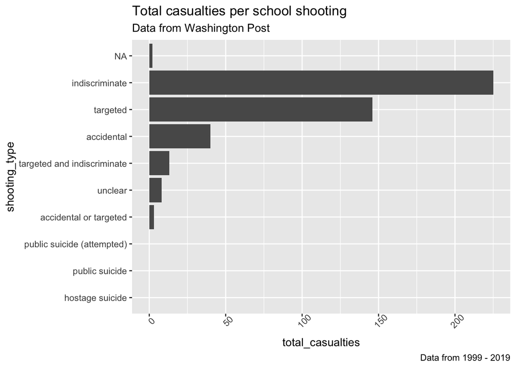

```r
school_shootings%>%
  group_by(shooting_type) %>%  #This one takes only the shooting type
  summarise(total_casualties= sum(casualties)) %>% #This function summaries all the casualties into a category named total_casualties
  mutate(shooting_type=reorder(shooting_type, total_casualties)) %>%
  ggplot(aes(x=shooting_type, y=total_casualties)) +
  geom_col()+
  theme(axis.text.x = element_text(angle = 45))+ #This function turns the shooting_type
  coord_flip()+ #This function flips the to horizontal
  labs(title = "Total casualties per school shooting", subtitle = "Data from Washington Post", caption = "Data from 1999 - 2019")
```

#This could probably be one of the best to show the casualties divided into the different shooting types. This would be more relevant if we went with the same definition of school shooting as the author Poland.